# Association between variables

## Example of 0 correlation

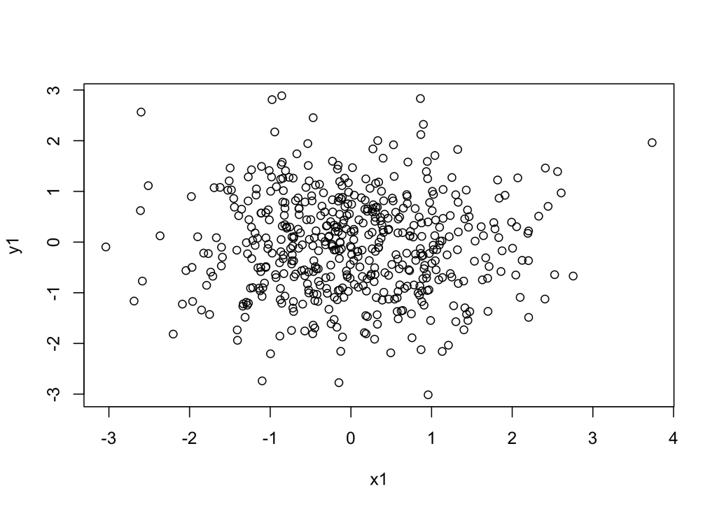

```r
x1=rnorm(500)
y1=rnorm(500)
plot(x1,y1)
```

```r
cor(x1, y1)
```

```
## [1] 0.0005627502
```

## Correlation does not imply causation

Website with numerous [spurious correlations](https://tylervigen.com/spurious-correlations)

# Rank correlations

> The problems with Pearson correlation are that it is not suitable for “strange” non-linear relationships, non-normally distributed traits and data with outliers.

## Spearman correlation

- Suitable for non-linear relationships
- Less sensitive to outliers
- Calculated based on ranks

## Examples

### Non-linear

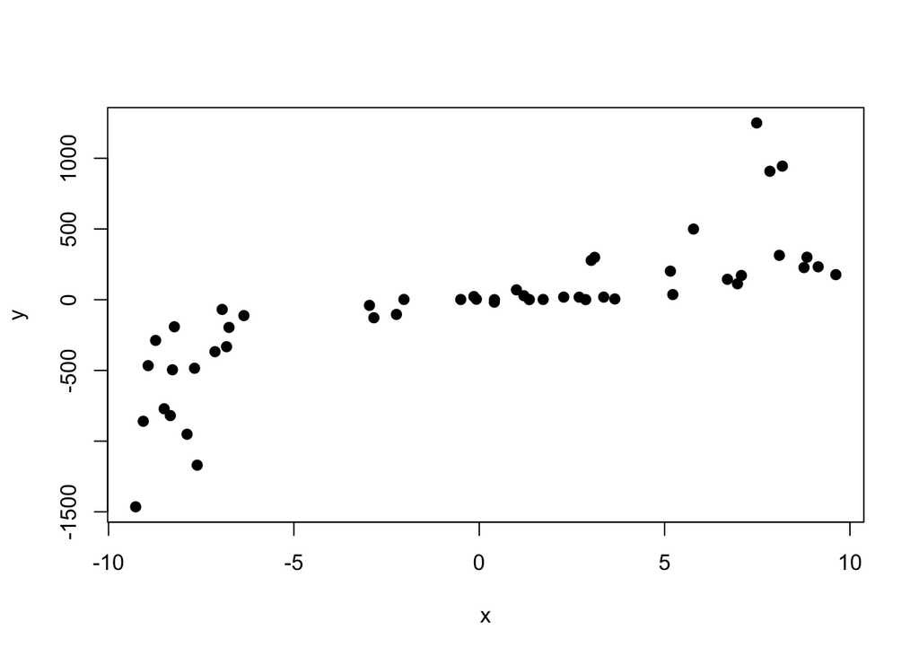

```r
x = runif(50, -10, 10)
y = (x + rnorm(50, 0, 2))^3
plot(x,y, pch=19)
```

```r
cor(x,y)
```

```
## [1] 0.8022729
```

```r
cor(x,y, method = "spearman")
```

```
## [1] 0.9286435
```

```r
# cor(x,y, method = "kendall")
```

### With outliers

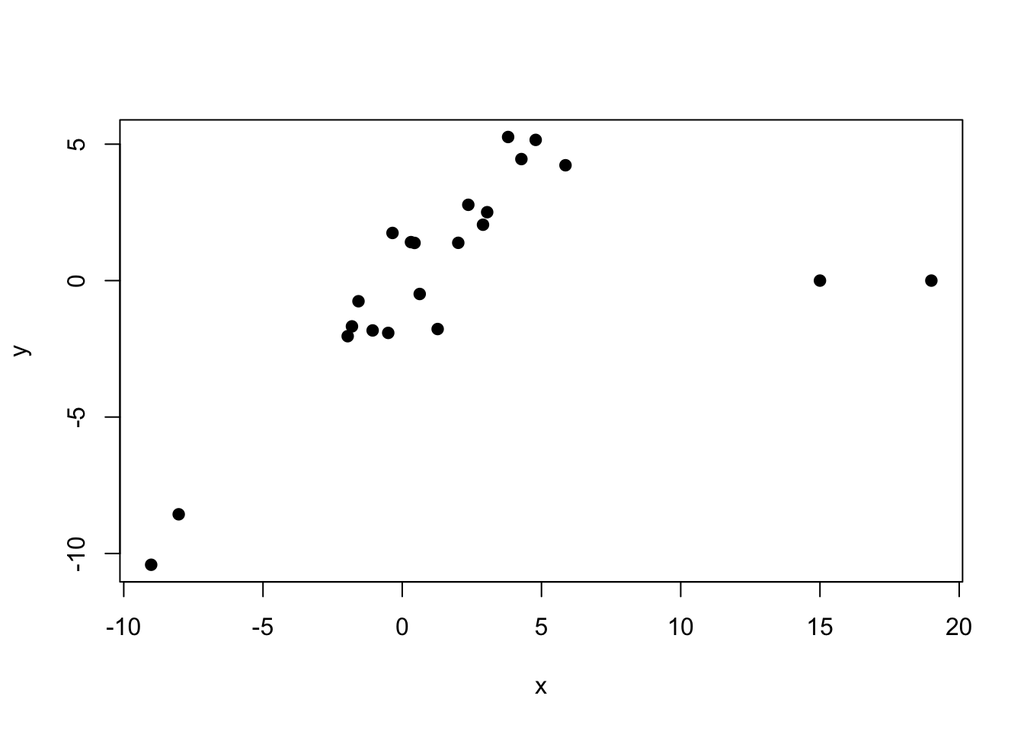

```r
x = c(rnorm(20,0,3), c(15, 19))
y = c(x[1:20] + c(rnorm(20,0,1)), 0, 0)
plot(x,y, pch=19)
```

```r
cor(x,y)
```

```
## [1] 0.555594
```

```r
cor(x,y, method = "spearman")
```

```
## [1] 0.7512003
```

```r
# cor(x,y, method = "kendall")
```

> By conducting correlation analysis, we only answered the question “Is there a significant relationship between the values?”. Can we, using this knowledge, predict the values of one variable based on the second variable? **Yes!**

# Linear Regression

Used to predict a continuous outcome based on one *or more* predictors.

## Formula

$y = \beta_0 + \beta_1x_1 + ... + \beta_nx_n + \epsilon$

- $y$ - dependent variable (response)
- $x$ - independent variable (predictor)
- $\beta_0$ - intercept - value of $y$, when $x=0$
- $\beta_i$ - **coefficients** - values by which $y$ is changed when the corresponding $x_i$ is increased by 1.
- $\epsilon$ - so-called **error -** differences between real $y$ values and esimated by model values

## Formula of model (linear)

$y_{pred} = \beta_0 + \beta_1x_1 + ... + \beta_nx_n$

## Assumptions

- **Homoscedasticity: Residuals have constant variance (~)** - $\sigma^2(\epsilon) = const$
- **Mean of residuals** is close to **zero**
  - *Stricter assumption*: residuals are normally distributed around zero **(~)** - $\epsilon \sim Norm(0, \sigma^2)$  
    This assumption is equivalent to normality of $y$
- Observations $y_i$ are **independent** (not correlated) **(~)**
- **Linearity**: The relationship between variables is considered to be linear.

> **(~) denotes assumptions needed for hypotheses testing and confidence estimation only**

# Simple linear regression

Linear regression model with **one dependent** $y$ (response) and one **independent** variable $x$ (predictor). Simple line which estimate linear relationship between $x$ and $y$.

## Formula of model

$y_{pred} = \beta_0 + \beta_1x_1$

## Can plant height be predicted based on soil nutrient levels?

### Data

```r
nutrients <- rnorm(50, mean = 10, sd = 3)
height <- 2 * nutrients + rnorm(50, mean = 0, sd = 5)

data_plant_nutrient <- data.frame(nutrients, height)
```

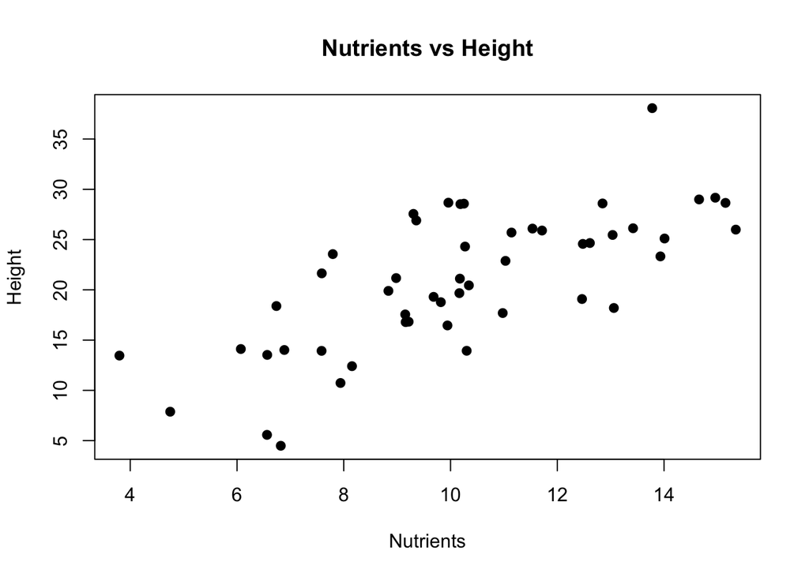

```r
plot(nutrients, height, main = "Nutrients vs Height",
     xlab = "Nutrients", ylab = "Height",
     pch=19)
```

### Model creation

```r
model <- lm(height ~ nutrients, data = data_plant_nutrient)
model
```

```
##
## Call:
## lm(formula = height ~ nutrients, data = data_plant_nutrient)
##
## Coefficients:
## (Intercept)    nutrients
##       2.744        1.777
```

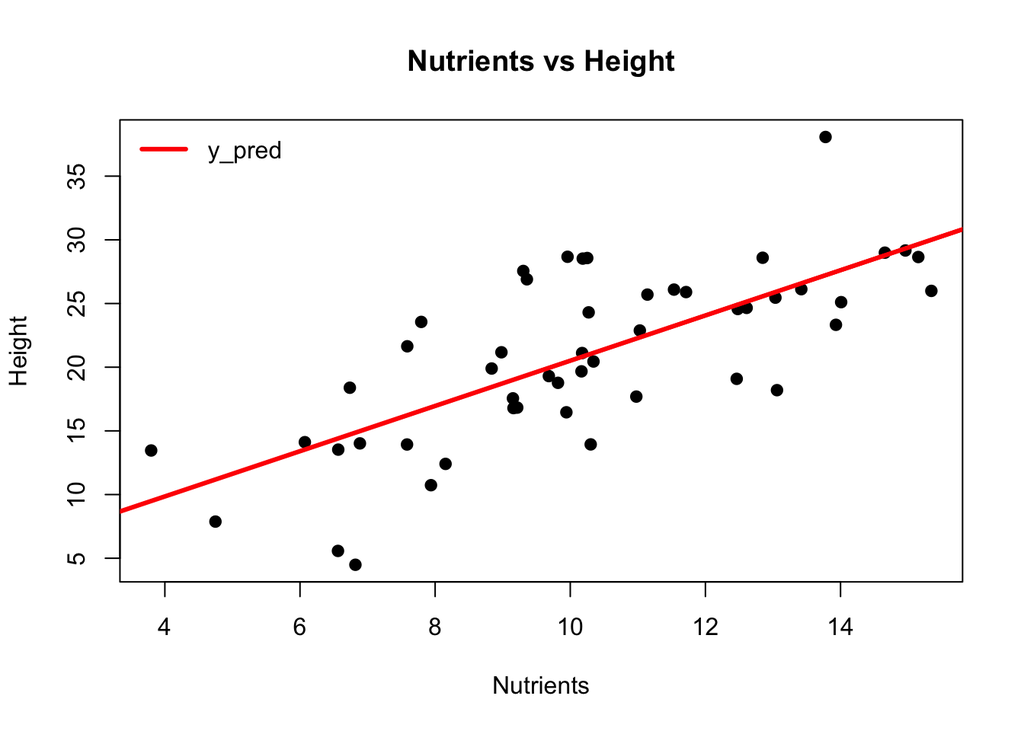

```r
plot(nutrients, height, main = "Nutrients vs Height",
     xlab = "Nutrients", ylab = "Height",
     pch=19)
abline(model, col = "red", lwd=3)
legend("topleft",
       legend = c("y_pred"),
       col = c('red'),
       bty = 'n', lwd=3)
```

# Model summary

```r
summary_model = summary(model)
summary_model
```

```
##
## Call:
## lm(formula = height ~ nutrients, data = data_plant_nutrient)
##
## Residuals:
##      Min       1Q   Median       3Q      Max
## -10.3767  -2.4736  -0.4826   2.9746  10.8438
##
## Coefficients:
##             Estimate Std. Error t value Pr(>|t|)
## (Intercept)   2.7443     2.5965   1.057    0.296
## nutrients     1.7771     0.2456   7.236  3.2e-09 ***
## ---
## Signif. codes:  0 '***' 0.001 '**' 0.01 '*' 0.05 '.' 0.1 ' ' 1
##
## Residual standard error: 4.766 on 48 degrees of freedom
## Multiple R-squared:  0.5217, Adjusted R-squared:  0.5118
## F-statistic: 52.36 on 1 and 48 DF,  p-value: 3.198e-09
```

### Residuals

> Difference between values of observed data ($y_i$) and estimated by linear model values $y_{pred,\space i}$ for each $x_i$
- $y_i-y_{pred,\space i}$

```r
# model$residuals
residuals(model)
```

[output not shown]

### Coefficients:

> Estimate the effect of $x$ on the value of $y$.

Their values are estimated to minimize $MSE = \sum (y_i - y_{pred,\space i})^2$ **(Squared sum of errors)**

```r
# model$coefficients
coefficients(model)
```

```
## (Intercept)   nutrients
##    2.744288    1.777133
```

### p-values Pr(>|t|): Test the null hypothesis that coefficients are zero (t-test).

$$t = \dfrac{Estimated\space
coefficient}{Std. Error} =
\dfrac{\beta_i}{\sqrt{\frac{\sigma_{residuals}}{\sum(x_i-\overline{x})^2}}}
= \dfrac{\beta_i}{\sqrt{\frac{1}{n-2}*\frac{\sum(y_i-y_{pred,\space
i})^2}{\sum(x_i-\overline{x})^2}}}$$

- More informative for slope than for intercept

```r
# summary_model$coefficients[,3:4]
summary_model$coefficients
```

```
##             Estimate Std. Error  t value     Pr(>|t|)
## (Intercept) 2.744288  2.5964885 1.056923 2.958373e-01
## nutrients   1.777133  0.2455923 7.236112 3.198101e-09
```

### Residual standard error

$$Residual\space Standard\space
Error\space (RSE) = \sqrt{\dfrac{\sum (y_i -
y_{pred})^2}{df}}$$

$df = n - p$, where $n$ - number of observations and $p$ is number of estimated parameters (in our case they are **slope** and **intercept).**

```r
summary_model$sigma
```

```
## [1] 4.766119
```

### R-squared

> Proportion of variance explained by the model

$$R^2 = 1 - \dfrac{\sum(y_i -
y_{pred})^2}{\sum(y_i-\overline{y})^2} = 1-\dfrac{SSR}{SST}$$

- For simple linear regression is equal to squared Pearson correlation coefficient $\rho^2$

```r
summary_model$r.squared
```

```
## [1] 0.5217281
```

### Adjusted R-squared:

> Penalizes for the number of predictors to avoid overestimating the model’s explanatory power when additional (possibly irrelevant) predictors are added

$$\overline{R}^2 = 1 -
\dfrac{\dfrac{\sum(y_i -
y_{pred})^2}{n-p}}{\dfrac{\sum(y_i-\overline{y})^2}{n-1}} =
1-\dfrac{\dfrac{SSR}{n-p}}{\dfrac{SST}{n-1}}$$

$p$ - number of parameters, $n$ - number of observations

```r
summary_model$adj.r.squared
```

```
## [1] 0.5117641
```

### F-statistic

> Tests the overall significance of the regression model.

$$F = \dfrac{\frac{\sum(\overline y -
y_{pred,\space i})^2}{p-1}}{\frac{\sum(y_i-y_{pred,\space i})^2}{n-p}} =
\dfrac{\frac{SSR}{p-1}}{\frac{SSE}{n-p}} = \dfrac{MSR}{MSE}$$

$p$ - number of parameters, $n$ - number of observations

- *p-values* are calculated according to **Fisher distribution**
- In simple linear regression, it is equivalent to the t-test for the slope.

```r
# pf(summary_model$fstatistic[1], summary_model$fstatistic[2],
   # summary_model$fstatistic[3], lower.tail = FALSE)

summary_model$fstatistic
```

```
##    value    numdf    dendf
## 52.36132  1.00000 48.00000
```

> *A higher F-statistic indicates that the model’s explained variability (MSR - Regression mean squares) is large relative to the unexplained variability (MSE - Mean of squares error), suggesting that the regression model is capturing a significant relationship.*

#### F-test

```r
anova(model)
```

```
## Analysis of Variance Table
##
## Response: height
##           Df Sum Sq Mean Sq F value    Pr(>F)
## nutrients  1 1189.4 1189.43  52.361 3.198e-09 ***
## Residuals 48 1090.4   22.72
## ---
## Signif. codes:  0 '***' 0.001 '**' 0.01 '*' 0.05 '.' 0.1 ' ' 1
```

# Multiple Linear Regression

Several independent variables (predictors)

## Formula of model

$y_{pred} = \beta_0 + \beta_1x_1 + ... + \beta_nx_n$

## Adding one more predictor for plant height model

```r
sunlight_hrs = rep(5:9, each=10) + rnorm(50, 0, 1)
data_plant_nutrient = data_plant_nutrient %>% arrange(height) %>%  cbind(sunlight_hrs)
data_plant_nutrient %>% str()
```

```
## 'data.frame':    50 obs. of  3 variables:
##  $ nutrients   : num  6.82 6.56 4.75 7.94 8.15 ...
##  $ height      : num  4.49 5.58 7.88 10.74 12.41 ...
##  $ sunlight_hrs: num  4.6 5.5 6.2 3.79 5.9 ...
```

[figure not shown]

```r
plot(data_plant_nutrient$height, data_plant_nutrient$sunlight_hrs,
     main = "Sunlight vs Height",
     xlab = "Sunlight", ylab = "Height",
     pch=19)
```

### Additive

$$y = \beta_0 + \beta_1x_1 + \beta_2x_2$$

```r
model_mullti = lm(height ~ sunlight_hrs + nutrients, data = data_plant_nutrient)
summary(model_mullti)
```

```
##
## Call:
## lm(formula = height ~ sunlight_hrs + nutrients, data = data_plant_nutrient)
##
## Residuals:
##    Min     1Q Median     3Q    Max
## -9.148 -2.160 -0.966  2.328 10.480
##
## Coefficients:
##              Estimate Std. Error t value Pr(>|t|)
## (Intercept)   -3.6318     2.6192  -1.387 0.172099
## sunlight_hrs   2.0479     0.4578   4.474 4.86e-05 ***
## nutrients      1.0814     0.2596   4.166 0.000132 ***
## ---
## Signif. codes:  0 '***' 0.001 '**' 0.01 '*' 0.05 '.' 0.1 ' ' 1
##
## Residual standard error: 4.034 on 47 degrees of freedom
## Multiple R-squared:  0.6646, Adjusted R-squared:  0.6503
## F-statistic: 46.56 on 2 and 47 DF,  p-value: 7.107e-12
```

### With interaction

$$y = \beta_0 + \beta_1x_1 + \beta_2x_2 +
\beta_3x_1x_2$$

**Now coefficient have different interpretation:**

- $\beta_1$: Effect of $x_1$ on $y$ when $x_2=0$.
- $\beta_2$: Effect of $x_2$ on $y$ when $x_1=0$.
- $\beta_3$: **Interaction coefficient**, showing how the relationship between $x_1$ and $y$ changes as $x_2$ changes.

> You should include an interaction if you hypothesize that the relationship between one predictor and the dependent variable changes depending on the level of another predictor. For example, the effect of a drug might vary depending on the age of the patient.

```r
# model_mullti = lm(height ~ nutrients + sunlight_hrs + nutrients:sunlight_hrs, data = data_plant_nutrient)
model_mullti_interact = lm(height ~ nutrients * sunlight_hrs, data = data_plant_nutrient)
summary(model_mullti_interact)
```

```
##
## Call:
## lm(formula = height ~ nutrients * sunlight_hrs, data = data_plant_nutrient)
##
## Residuals:
##    Min     1Q Median     3Q    Max
## -8.817 -2.014 -0.966  2.437 10.800
##
## Coefficients:
##                        Estimate Std. Error t value Pr(>|t|)
## (Intercept)            -15.1616     9.6034  -1.579   0.1212
## nutrients                2.2380     0.9626   2.325   0.0245 *
## sunlight_hrs             3.8403     1.5074   2.548   0.0143 *
## nutrients:sunlight_hrs  -0.1731     0.1388  -1.247   0.2186
## ---
## Signif. codes:  0 '***' 0.001 '**' 0.01 '*' 0.05 '.' 0.1 ' ' 1
##
## Residual standard error: 4.01 on 46 degrees of freedom
## Multiple R-squared:  0.6755, Adjusted R-squared:  0.6544
## F-statistic: 31.92 on 3 and 46 DF,  p-value: 2.607e-11
```

- `x1:x2` denotes interaction
- `x1 * x2` is equivalent to `x1 + x2 + x1:x2`

## Testing if model is better with new predictors

```r
anova(model, model_mullti_interact)
```

```
## Analysis of Variance Table
##
## Model 1: height ~ nutrients
## Model 2: height ~ nutrients * sunlight_hrs
##   Res.Df    RSS Df Sum of Sq      F    Pr(>F)
## 1     48 1090.4
## 2     46  739.7  2    350.66 10.903 0.0001331 ***
## ---
## Signif. codes:  0 '***' 0.001 '**' 0.01 '*' 0.05 '.' 0.1 ' ' 1
```

- $p.value < 0.05$ and it means that new model better reduce the residual variance

## Plot the line “without” modelling

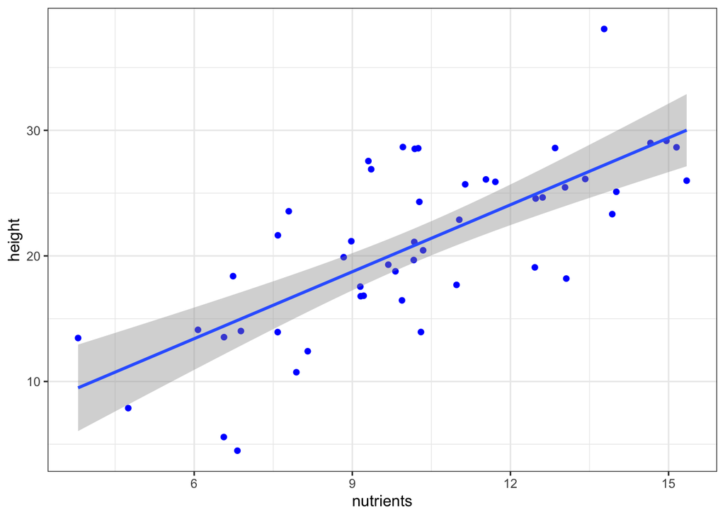

```r
data_plant_nutrient %>%
  ggplot(aes(x=nutrients, y=height)) +
  geom_point(col='blue', show.legend = T) +
  geom_smooth(formula = y ~ x, method = 'lm', show.legend = T) + ## <---- creates model and plots the line
  theme_bw()
```